# Estimation

## Estimation

### Ex. 1

The dataset teengamb concerns a study of teenage gambling in Britain. Fit a regression model with the expenditure on gambling as the response and the sex, status, income and verbal score as predictors.

Present the output

```r
data %>%
  select(gamble, income, verbal, sex, status) %>%
  cor()
```

```
            gamble     income     verbal        sex      status
gamble  1.00000000  0.6220769 -0.2200562 -0.4078053 -0.05042081
income  0.62207690  1.0000000 -0.1755707 -0.1154586 -0.27503402
verbal -0.22005619 -0.1755707  1.0000000 -0.1069762  0.53161022
sex    -0.40780533 -0.1154586 -0.1069762  1.0000000 -0.48093526
status -0.05042081 -0.2750340  0.5316102 -0.4809353  1.00000000
```

```r
library(moderndive)

# fit regression model

gamble_model <- lm(gamble ~ sex + income + verbal + status, data = data)

# regression table

get_regression_table(gamble_model)
```

| term | estimate | std_error | statistic | p_value | lower_ci | upper_ci |
| --- | --- | --- | --- | --- | --- | --- |
| intercept | 22.556 | 17.197 | 1.312 | 0.197 | -12.149 | 57.260 |
| sex | -22.118 | 8.211 | -2.694 | 0.010 | -38.689 | -5.548 |
| income | 4.962 | 1.025 | 4.839 | 0.000 | 2.893 | 7.031 |
| verbal | -2.959 | 2.172 | -1.362 | 0.180 | -7.343 | 1.424 |
| status | 0.052 | 0.281 | 0.186 | 0.853 | -0.515 | 0.620 |

Estimate -> 22.556 it represents the gamble expenditure when sex, income, verbal and status are at 0.

[output not shown]

[output cut: 37 more lines]

1. What percentage of variation in the response is explained by these predictors?

```r
get_regression_points(gamble_model) %>%
  summarize(var_y = var(gamble),
            var_y_hat = var(gamble_hat),
            var_residual = var(residual))
```

| var_y | var_y_hat | var_residual |
| --- | --- | --- |
| 993.2498 | 523.1693 | 470.0798 |

```r
NA
```

2. Which observation has the largest (positive) residual? Give the case number.

```r
#24 156.00  0   10.00   4   27  61.748  94.252
```

3. Compute the mean and median of the residuals.
4. Compute the correlation of the residuals with the fitted values.
5. Compute the correlation of the residuals with the income.
6. For all other predictors held constant, what would be the difference in predicted expenditure on gambling for a male compared to a female

```r
library(faraway)
library(tidyverse)
library(skimr)

data <- teengamb
```

```r
data %>% skim()
```

```
-- Data Summary ------------------------
                           Values
Name                       Piped data
Number of rows             47
Number of columns          5
_______________________
Column type frequency:
  numeric                  5
________________________
Group variables            None

-- Variable type: numeric ----------------------------------------------------------------------------------
# A tibble: 5 x 11
  skim_variable n_missing complete_rate   mean     sd    p0   p25   p50   p75  p100 hist
* <chr>             <int>         <dbl>  <dbl>  <dbl> <dbl> <dbl> <dbl> <dbl> <dbl> <chr>
1 sex                   0             1  0.404  0.496   0     0    0     1        1 ▇▁▁▁▆
2 status                0             1 45.2   17.3    18    28   43    61.5     75 ▇▅▇▃▆
3 income                0             1  4.64   3.55    0.6   2    3.25  6.21    15 ▇▃▂▂▁
4 verbal                0             1  6.66   1.86    1     6    7     8       10 ▁▂▆▇▃
5 gamble                0             1 19.3   31.5     0     1.1  6    19.4    156 ▇▁▁▁▁
```

- From the description above we can observe that sex, income and gamble have NOT normal distributions
- income and gamble skewed to the right
- sex categorical - dummy variable

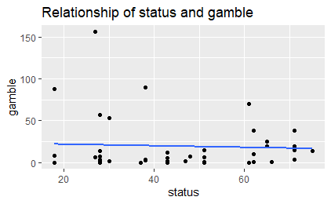

```r
data %>%
  ggplot(aes(x=status, y=gamble)) +
  geom_point() +
  labs(title = "Relationship of status and gamble") +
  geom_smooth(method = "lm", se = FALSE)
```

Relationship of Predictors with Gambling expenditure

- **Sex** -> 0 = male, 1= female, less female gambling expenditure
- status -> socioeconomic status based on parents occupation
- **income**
- **verbal** -> inverse (negative relationship)

### Ex. 2

5. Using the prostate data, plot lpsa against l cavol. Fit the regressions of lpsa on lcavol and lcavol on lpsa. Display both regression lines on the plot. At what point do the two lines intersect